# Overview

**Original request:**

*I have attached a rough draft of the methodology for the Happy Talk study with some research questions which hopefully will help make sense of the data.*

*I have put in the following questions and highlighted the outcomes. In some places there is an option to use just one outcome or to add in another. I don’t know if our numbers allow for a second outcome in some of these places, so statistically you might not advise it.*

*Research questions – Following completion of the Happy Talk programme*

*- Based on the PLS-5 composite scores, did the receptive and or expressive language of children from disadvantaged areas improve, when compared to a control group over the same period of time? PLS-5 outcomes*

*- Using the PedsQL and CHU9D, did children’s quality of life improve compared to a control group of children from similar backgrounds, who did not complete the programme? PEDsQL total score and then composites?*

*- Using the Detailed Code of Responsiveness, did parents increase their level of responsiveness when playing with their children, compared to a control group of parents who did not complete the programme? Rate per minute outcome and total number as a possible second for PedsQL*

*- When measured using the Communication Supporting Classroom Observation Tool (CSCOT) has the oral language environment of preschools increased when compared to control preschools in similar areas catering for a similar demographic. CSCOT score outcome* **Note: n = 4. There really isn’t an analysis possible here.**

**Note: The following two questions can not be usefully answered with these data.**

*- Are attendance rates associated with differential intervention outcome effects?*

*- Examining the influences of moderating or mediating influences on children’s intervention effects.*

# PLS-5

This section answers the following: *Based on the PLS-5 composite scores, did the receptive and or expressive language of children from disadvantaged areas improve, when compared to a control group over the same period of time? PLS-5 outcomes*

## PLS-5-AC

Figure. Individual level change in PLS-5-AC by study arm.

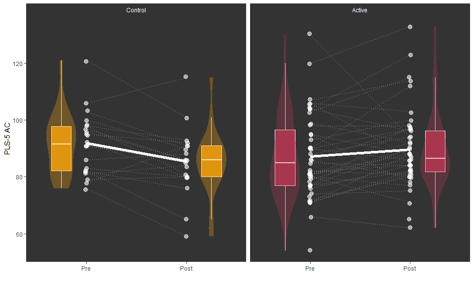

Table. Estimated effect of the intervention on PLS-5-AC scores.

|  | Baseline adjusted |  |  | Covariate adjusted |  |  |
| --- | --- | --- | --- | --- | --- | --- |
| Predictors | Estimates | CI | p | Estimates | CI | p |
| Intercept | 83.46 | 78.95 – 87.97 | **<0.001** | 83.91 | 79.25 – 88.57 | **<0.001** |
| Active (vs Control) | 8.04 | 2.47 – 13.61 | **0.005** | 8.15 | 2.44 – 13.86 | **0.006** |
| Baseline PLS-5-AC | 0.68 | 0.48 – 0.88 | **<0.001** | 0.64 | 0.43 – 0.86 | **<0.001** |
| Age (m) |  |  |  | -0.13 | -0.56 – 0.30 | 0.557 |
| Previous SLT (vs None) |  |  |  | -2.85 | -10.12 – 4.43 | 0.436 |
| Observations | 58 |  |  | 58 |  |  |
| R<sup>2</sup> / R<sup>2</sup> adjusted | 0.480 / 0.461 |  |  | 0.489 / 0.451 |  |  |

## PLS-5-ES

Figure. Individual level change in PLS-5-ES by study arm.

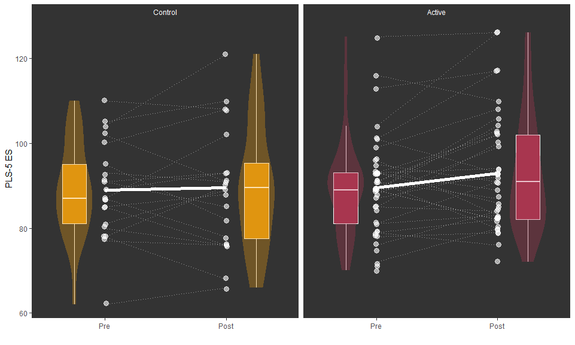

Table. Estimated effect of the intervention on PLS-5-ES scores.

|  | Baseline adjusted |  |  | Covariate adjusted |  |  |
| --- | --- | --- | --- | --- | --- | --- |
| Predictors | Estimates | CI | p | Estimates | CI | p |
| Intercept | 89.86 | 85.88 – 93.85 | **<0.001** | 89.78 | 85.65 – 93.90 | **<0.001** |
| Active (vs Control) | 2.89 | -2.16 – 7.94 | 0.256 | 2.76 | -2.47 – 7.99 | 0.294 |
| Baseline PLS-5-ES | 0.95 | 0.73 – 1.17 | **<0.001** | 0.96 | 0.72 – 1.19 | **<0.001** |
| Age (m) |  |  |  | -0.02 | -0.42 – 0.39 | 0.940 |
| Previous SLT (vs None) |  |  |  | 0.96 | -5.83 – 7.75 | 0.777 |
| Observations | 54 |  |  | 54 |  |  |
| R<sup>2</sup> / R<sup>2</sup> adjusted | 0.615 / 0.600 |  |  | 0.616 / 0.584 |  |  |

## PLS-5-Total

Figure. Individual level change in PLS-5-Total by study arm.

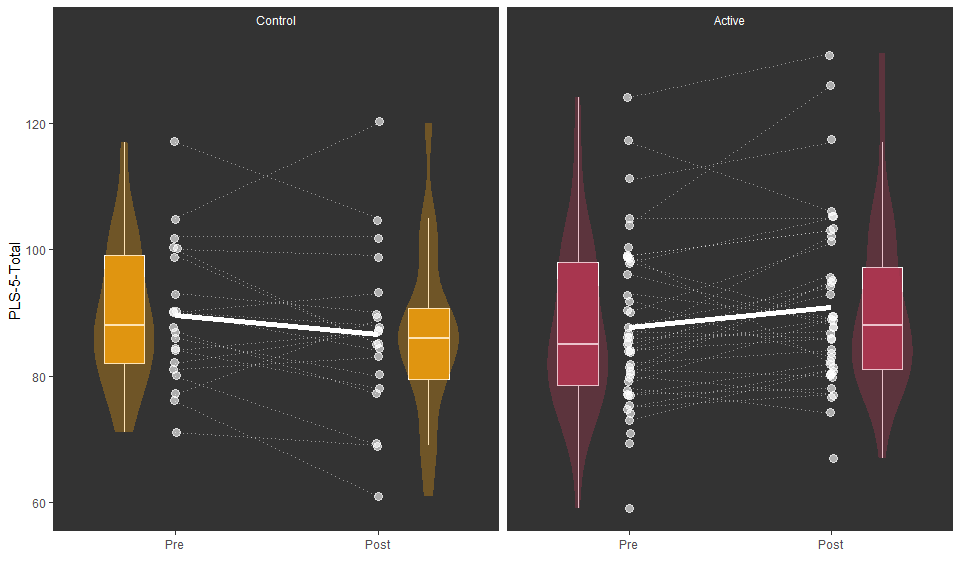

Table. Estimated effect of the intervention on PLS-5-Total scores.

|  | Baseline adjusted |  |  | Covariate adjusted |  |  |
| --- | --- | --- | --- | --- | --- | --- |
| Predictors | Estimates | CI | p | Estimates | CI | p |
| Intercept | 85.33 | 81.57 – 89.09 | **<0.001** | 85.39 | 81.48 – 89.30 | **<0.001** |
| Active (vs Control) | 6.29 | 1.56 – 11.01 | **0.010** | 6.21 | 1.32 – 11.10 | **0.014** |
| Baseline PLS-5-Total | 0.89 | 0.70 – 1.08 | **<0.001** | 0.88 | 0.68 – 1.09 | **<0.001** |
| Age (m) |  |  |  | -0.07 | -0.45 – 0.30 | 0.695 |
| Previous SLT (vs None) |  |  |  | -0.11 | -6.58 – 6.36 | 0.974 |
| Observations | 54 |  |  | 54 |  |  |
| R<sup>2</sup> / R<sup>2</sup> adjusted | 0.645 / 0.631 |  |  | 0.646 / 0.617 |  |  |

# QOL

This section answers the following:

*- Using the PedsQL and CHU9D, did children’s quality of life improve compared to a control group of children from similar backgrounds, who did not complete the programme? PEDsQL total score and then composites?*

## PEDsQL-Psychosocial

Figure. Individual level change in PEDsQL-Psychosocial scores by study arm.

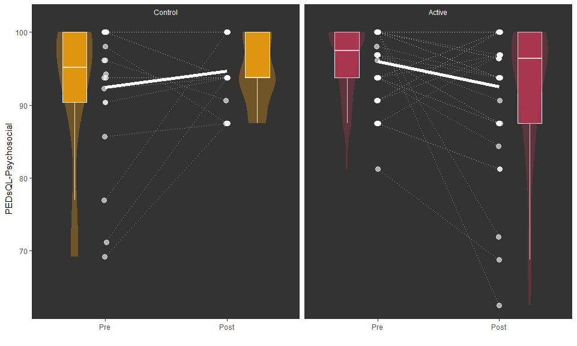

Table. Estimated effect of the intervention on PEDsQL-Psychosocial scores.

**Logistic (Proportional Odds) Ordinal Regression Model**

```
 orm(formula = post_peds_psychosocial ~ arm + center(peds_psychosocial_pre),
     data = data)
```

Frequencies of Responses

```
  62.5 68.75 71.88 81.25 84.37  87.5 90.63 93.75 96.43 96.87 96.88   100
     1     1     1     2     1     7     2    13     3     1     3    15
```

Frequencies of Missing Values Due to Each Variable

```
 post_peds_psychosocial                    arm  peds_psychosocial_pre
                     28                      0                     19
```

|  | Model Likelihood Ratio Test | Discrimination Indexes | Rank Discrim. Indexes |
| --- | --- | --- | --- |
| Obs 50 | LR χ<sup>2</sup> 3.50 | *R*<sup>2</sup> 0.069 | ρ 0.243 |
| Distinct *Y* 12 | d.f. 2 | *g* 0.524 |  |
| *Y*<sub>0.5</sub> 93.75 | Pr(>χ<sup>2</sup>) 0.1737 | *g*<sub>r</sub> 1.689 |  |
| max \|∂log *L*/∂β\| 2×10<sup>-6</sup> | Score χ<sup>2</sup> 3.62 | \|Pr(*Y* ≥ median)-½\| 0.205 |  |
|  | Pr(>χ<sup>2</sup>) 0.1639 |  |  |

|  | β | S.E. | Wald *Z* | Pr(>\|*Z*\|) |
| --- | --- | --- | --- | --- |
| arm=Active | -0.4345 | 0.5726 | -0.76 | 0.4480 |
| peds_psychosocial_pre | 0.0684 | 0.0371 | 1.85 | 0.0650 |

**Logistic (Proportional Odds) Ordinal Regression Model**

```
 orm(formula = post_peds_psychosocial ~ arm + center(peds_psychosocial_pre) +
     center(age_in_months) + previous_slt_involvement, data = data)
```

Frequencies of Responses

```
  62.5 68.75 71.88 81.25 84.37  87.5 90.63 93.75 96.43 96.87 96.88   100
     1     1     1     2     1     7     2    13     3     1     3    15
```

Frequencies of Missing Values Due to Each Variable

```
   post_peds_psychosocial                      arm    peds_psychosocial_pre
                       28                        0                       19
            age_in_months previous_slt_involvement
                        0                        0
```

|  | Model Likelihood Ratio Test | Discrimination Indexes | Rank Discrim. Indexes |
| --- | --- | --- | --- |
| Obs 50 | LR χ<sup>2</sup> 8.82 | *R*<sup>2</sup> 0.165 | ρ 0.339 |
| Distinct *Y* 12 | d.f. 4 | *g* 0.873 |  |
| *Y*<sub>0.5</sub> 93.75 | Pr(>χ<sup>2</sup>) 0.0658 | *g*<sub>r</sub> 2.395 |  |
| max \|∂log *L*/∂β\| 3×10<sup>-5</sup> | Score χ<sup>2</sup> 9.18 | \|Pr(*Y* ≥ median)-½\| 0.224 |  |
|  | Pr(>χ<sup>2</sup>) 0.0569 |  |  |

|  | β | S.E. | Wald *Z* | Pr(>\|*Z*\|) |
| --- | --- | --- | --- | --- |
| arm=Active | -0.3796 | 0.5787 | -0.66 | 0.5119 |
| peds_psychosocial_pre | 0.0626 | 0.0376 | 1.66 | 0.0959 |
| age_in_months | -0.1036 | 0.0501 | -2.07 | 0.0386 |
| previous_slt_involvement=yes | -0.3269 | 0.6450 | -0.51 | 0.6123 |

## PEDsQL-Physical

Figure. Individual level change in PEDsQL-Physical scores by study arm.

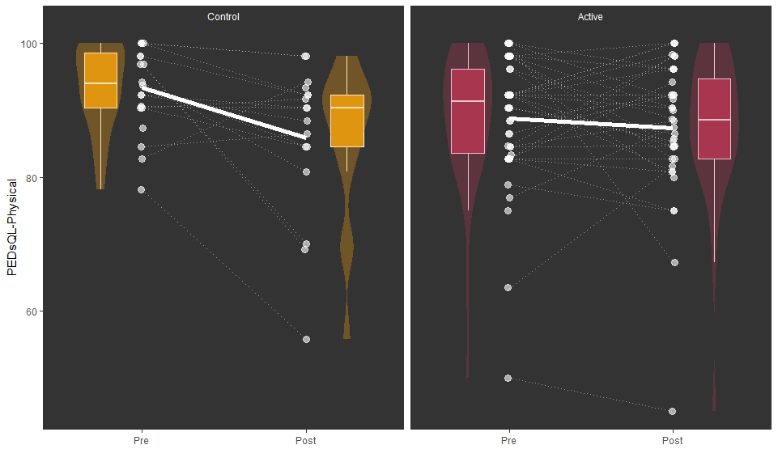

Table. Estimated effect of the intervention on PEDsQL-Physical scores.

**Logistic (Proportional Odds) Ordinal Regression Model**

```
 orm(formula = post_peds_physical ~ arm + center(peds_physical_pre),
     data = data)
```

Frequencies of Missing Values Due to Each Variable

```
 post_peds_physical                arm  peds_physical_pre
                 28                  0                 19
```

|  | Model Likelihood Ratio Test | Discrimination Indexes | Rank Discrim. Indexes |
| --- | --- | --- | --- |
| Obs 50 | LR χ<sup>2</sup> 8.53 | *R*<sup>2</sup> 0.157 | ρ 0.297 |
| Distinct *Y* 28 | d.f. 2 | *g* 0.878 |  |
| *Y*<sub>0.5</sub> 88.46 | Pr(>χ<sup>2</sup>) 0.0140 | *g*<sub>r</sub> 2.407 |  |
| max \|∂log *L*/∂β\| 0.004 | Score χ<sup>2</sup> 9.41 | \|Pr(*Y* ≥ median)-½\| 0.144 |  |
|  | Pr(>χ<sup>2</sup>) 0.0090 |  |  |

|  | β | S.E. | Wald *Z* | Pr(>\|*Z*\|) |
| --- | --- | --- | --- | --- |
| arm=Active | 0.5322 | 0.5416 | 0.98 | 0.3258 |
| peds_physical_pre | 0.0902 | 0.0311 | 2.90 | 0.0038 |

**Logistic (Proportional Odds) Ordinal Regression Model**

```
 orm(formula = post_peds_physical ~ arm + center(peds_physical_pre) +
     center(age_in_months) + previous_slt_involvement, data = data)
```

Frequencies of Missing Values Due to Each Variable

```
       post_peds_physical                      arm        peds_physical_pre
                       28                        0                       19
            age_in_months previous_slt_involvement
                        0                        0
```

|  | Model Likelihood Ratio Test | Discrimination Indexes | Rank Discrim. Indexes |
| --- | --- | --- | --- |
| Obs 50 | LR χ<sup>2</sup> 8.54 | *R*<sup>2</sup> 0.157 | ρ 0.289 |
| Distinct *Y* 28 | d.f. 4 | *g* 0.878 |  |
| *Y*<sub>0.5</sub> 88.46 | Pr(>χ<sup>2</sup>) 0.0736 | *g*<sub>r</sub> 2.406 |  |
| max \|∂log *L*/∂β\| 0.004 | Score χ<sup>2</sup> 9.43 | \|Pr(*Y* ≥ median)-½\| 0.144 |  |
|  | Pr(>χ<sup>2</sup>) 0.0511 |  |  |

|  | β | S.E. | Wald *Z* | Pr(>\|*Z*\|) |
| --- | --- | --- | --- | --- |
| arm=Active | 0.5345 | 0.5546 | 0.96 | 0.3351 |
| peds_physical_pre | 0.0899 | 0.0314 | 2.87 | 0.0041 |
| age_in_months | -0.0014 | 0.0515 | -0.03 | 0.9777 |
| previous_slt_involvement=yes | -0.0589 | 0.6783 | -0.09 | 0.9308 |

## PEDsQL-Total

Figure. Individual level change in PEDsQL-Total scores by study arm.

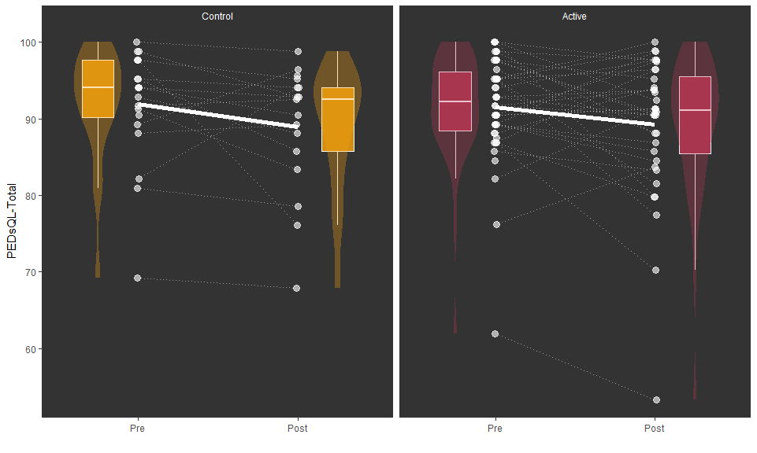

Table. Estimated effect of the intervention on PEDsQL-Total scores.

**Logistic (Proportional Odds) Ordinal Regression Model**

```
 orm(formula = post_peds_tot ~ arm + center(peds_tot_pre), data = data)
```

Frequencies of Missing Values Due to Each Variable

```
 post_peds_tot           arm  peds_tot_pre
            28             0            19
```

|  | Model Likelihood Ratio Test | Discrimination Indexes | Rank Discrim. Indexes |
| --- | --- | --- | --- |
| Obs 50 | LR χ<sup>2</sup> 13.59 | *R*<sup>2</sup> 0.238 | ρ 0.328 |
| Distinct *Y* 33 | d.f. 2 | *g* 1.161 |  |
| *Y*<sub>0.5</sub> 90.79 | Pr(>χ<sup>2</sup>) 0.0011 | *g*<sub>r</sub> 3.192 |  |
| max \|∂log *L*/∂β\| 3×10<sup>-5</sup> | Score χ<sup>2</sup> 15.48 | \|Pr(*Y* ≥ median)-½\| 0.164 |  |
|  | Pr(>χ<sup>2</sup>) 0.0004 |  |  |

|  | β | S.E. | Wald *Z* | Pr(>\|*Z*\|) |
| --- | --- | --- | --- | --- |
| arm=Active | 0.1958 | 0.5197 | 0.38 | 0.7063 |
| peds_tot_pre | 0.1487 | 0.0411 | 3.62 | 0.0003 |

**Logistic (Proportional Odds) Ordinal Regression Model**

```
 orm(formula = post_peds_tot ~ arm + center(peds_tot_pre) + center(age_in_months) +
     previous_slt_involvement, data = data)
```

Frequencies of Missing Values Due to Each Variable

```
            post_peds_tot                      arm             peds_tot_pre
                       28                        0                       19
            age_in_months previous_slt_involvement
                        0                        0
```

|  | Model Likelihood Ratio Test | Discrimination Indexes | Rank Discrim. Indexes |
| --- | --- | --- | --- |
| Obs 50 | LR χ<sup>2</sup> 13.86 | *R*<sup>2</sup> 0.242 | ρ 0.322 |
| Distinct *Y* 33 | d.f. 4 | *g* 1.168 |  |
| *Y*<sub>0.5</sub> 90.79 | Pr(>χ<sup>2</sup>) 0.0078 | *g*<sub>r</sub> 3.217 |  |
| max \|∂log *L*/∂β\| 2×10<sup>-5</sup> | Score χ<sup>2</sup> 16.14 | \|Pr(*Y* ≥ median)-½\| 0.163 |  |
|  | Pr(>χ<sup>2</sup>) 0.0028 |  |  |

|  | β | S.E. | Wald *Z* | Pr(>\|*Z*\|) |
| --- | --- | --- | --- | --- |
| arm=Active | 0.2486 | 0.5313 | 0.47 | 0.6399 |
| peds_tot_pre | 0.1463 | 0.0416 | 3.52 | 0.0004 |
| age_in_months | -0.0277 | 0.0532 | -0.52 | 0.6025 |
| previous_slt_involvement=yes | 0.0909 | 0.6534 | 0.14 | 0.8894 |

## CHU9D-Total

Figure. Individual level change in CHU9D-Total scores by study arm.

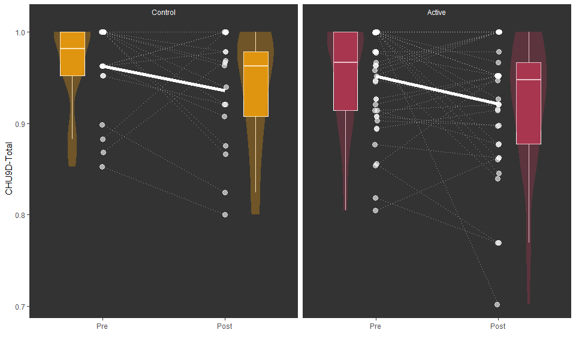

**Logistic (Proportional Odds) Ordinal Regression Model**

```
 orm(formula = post_chu9d_tot ~ arm + center(chu9d_tot_pre), data = data)
```

Frequencies of Missing Values Due to Each Variable

```
 post_chu9d_tot            arm  chu9d_tot_pre
             27              0             18
```

|  | Model Likelihood Ratio Test | Discrimination Indexes | Rank Discrim. Indexes |
| --- | --- | --- | --- |
| Obs 52 | LR χ<sup>2</sup> 7.13 | *R*<sup>2</sup> 0.128 | ρ 0.249 |
| Distinct *Y* 29 | d.f. 2 | *g* 0.749 |  |
| *Y*<sub>0.5</sub> 0.9475 | Pr(>χ<sup>2</sup>) 0.0283 | *g*<sub>r</sub> 2.116 |  |
| max \|∂log *L*/∂β\| 6×10<sup>-5</sup> | Score χ<sup>2</sup> 7.42 | \|Pr(*Y* ≥ median)-½\| 0.139 |  |
|  | Pr(>χ<sup>2</sup>) 0.0244 |  |  |

|  | β | S.E. | Wald *Z* | Pr(>\|*Z*\|) |
| --- | --- | --- | --- | --- |
| arm=Active | -0.1124 | 0.5392 | -0.21 | 0.8349 |
| chu9d_tot_pre | 12.3818 | 4.8916 | 2.53 | 0.0114 |

**Logistic (Proportional Odds) Ordinal Regression Model**

```
 orm(formula = post_chu9d_tot ~ arm + center(chu9d_tot_pre) +
     center(age_in_months) + previous_slt_involvement, data = data)
```

Frequencies of Missing Values Due to Each Variable

```
           post_chu9d_tot                      arm            chu9d_tot_pre
                       27                        0                       18
            age_in_months previous_slt_involvement
                        0                        0
```

|  | Model Likelihood Ratio Test | Discrimination Indexes | Rank Discrim. Indexes |
| --- | --- | --- | --- |
| Obs 52 | LR χ<sup>2</sup> 8.07 | *R*<sup>2</sup> 0.144 | ρ 0.347 |
| Distinct *Y* 29 | d.f. 4 | *g* 0.824 |  |
| *Y*<sub>0.5</sub> 0.9475 | Pr(>χ<sup>2</sup>) 0.0891 | *g*<sub>r</sub> 2.279 |  |
| max \|∂log *L*/∂β\| 3×10<sup>-5</sup> | Score χ<sup>2</sup> 8.28 | \|Pr(*Y* ≥ median)-½\| 0.145 |  |
|  | Pr(>χ<sup>2</sup>) 0.0817 |  |  |

|  | β | S.E. | Wald *Z* | Pr(>\|*Z*\|) |
| --- | --- | --- | --- | --- |
| arm=Active | -0.1248 | 0.5392 | -0.23 | 0.8170 |
| chu9d_tot_pre | 11.3253 | 5.0088 | 2.26 | 0.0238 |
| age_in_months | -0.0320 | 0.0470 | -0.68 | 0.4964 |
| previous_slt_involvement=yes | -0.3587 | 0.6690 | -0.54 | 0.5918 |

# Responsiveness

This section answers the following:

*- Using the Detailed Code of Responsiveness, did parents increase their level of responsiveness when playing with their children, compared to a control group of parents who did not complete the programme? Rate per minute outcome and total number as a possible second for PedsQL*

## Expansions

Figure. Individual level change in Expansions by study arm.

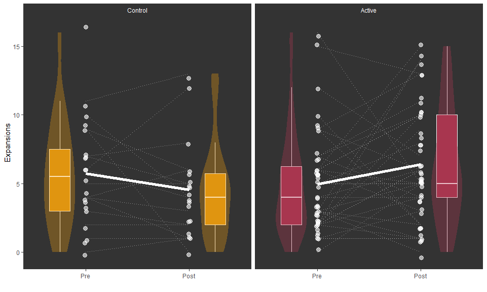

Table. Estimated effect of the intervention on Expansions.

|  | Baseline adjusted |  |  | Covariate adjusted |  |  |
| --- | --- | --- | --- | --- | --- | --- |
| Predictors | Estimates | CI | p | Estimates | CI | p |
| Intercept | 4.47 | 2.48 – 6.46 | **<0.001** | 4.26 | 2.19 – 6.33 | **<0.001** |
| Active (vs Control) | 1.83 | -0.56 – 4.22 | 0.130 | 1.85 | -0.63 – 4.33 | 0.140 |
| Baseline Expansions | 0.35 | 0.04 – 0.65 | **0.028** | 0.38 | 0.05 – 0.70 | **0.026** |
| Age (m) |  |  |  | 0.06 | -0.16 – 0.27 | 0.603 |
| Previous SLT (vs None) |  |  |  | 0.92 | -1.96 – 3.79 | 0.524 |
| Observations | 52 |  |  | 52 |  |  |
| R<sup>2</sup> / R<sup>2</sup> adjusted | 0.129 / 0.093 |  |  | 0.143 / 0.070 |  |  |

## Imitations

Figure. Individual level change in Imitations by study arm.

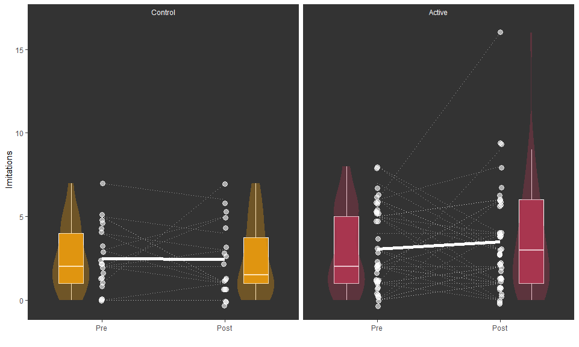

Table. Estimated effect of the intervention on Imitations.

|  | Baseline adjusted |  |  | Covariate adjusted |  |  |
| --- | --- | --- | --- | --- | --- | --- |
| Predictors | Estimates | CI | p | Estimates | CI | p |
| Intercept | 2.58 | 1.14 – 4.02 | **0.001** | 2.61 | 1.11 – 4.10 | **0.001** |
| Active (vs Control) | 0.69 | -1.05 – 2.43 | 0.429 | 0.82 | -0.97 – 2.61 | 0.363 |
| Baseline Imitations | 0.31 | -0.03 – 0.66 | 0.070 | 0.34 | -0.01 – 0.69 | 0.059 |
| Age (m) |  |  |  | 0.04 | -0.11 – 0.19 | 0.580 |
| Previous SLT (vs None) |  |  |  | -0.71 | -2.82 – 1.39 | 0.500 |
| Observations | 52 |  |  | 52 |  |  |
| R<sup>2</sup> / R<sup>2</sup> adjusted | 0.081 / 0.044 |  |  | 0.094 / 0.017 |  |  |

## Responsive Questions

Figure. Individual level change in Responsive Questions by study arm.

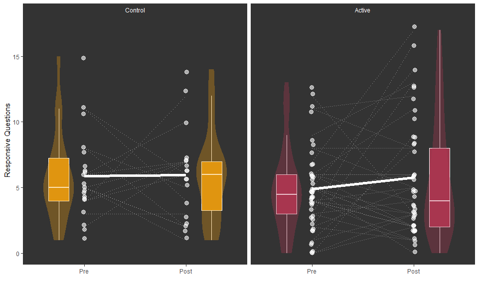

Table. Estimated effect of the intervention on Responsive Questions.

|  | Baseline adjusted |  |  | Covariate adjusted |  |  |
| --- | --- | --- | --- | --- | --- | --- |
| Predictors | Estimates | CI | p | Estimates | CI | p |
| Intercept | 5.30 | 3.17 – 7.43 | **<0.001** | 5.33 | 3.08 – 7.58 | **<0.001** |
| Active (vs Control) | 0.48 | -2.10 – 3.06 | 0.711 | 0.36 | -2.34 – 3.07 | 0.788 |
| Baseline Responsive Questions | 0.24 | -0.18 – 0.65 | 0.262 | 0.22 | -0.23 – 0.67 | 0.331 |
| Age (m) |  |  |  | -0.04 | -0.27 – 0.19 | 0.729 |
| Previous SLT (vs None) |  |  |  | 0.31 | -2.81 – 3.43 | 0.841 |
| Observations | 52 |  |  | 52 |  |  |
| R<sup>2</sup> / R<sup>2</sup> adjusted | 0.026 / -0.013 |  |  | 0.029 / -0.053 |  |  |

## Labels

Figure. Individual level change in Labels by study arm.

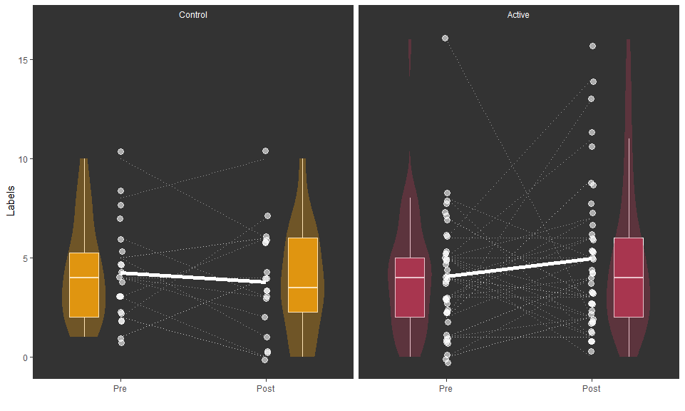

Table. Estimated effect of the intervention on Labels.

|  | Baseline adjusted |  |  | Covariate adjusted |  |  |
| --- | --- | --- | --- | --- | --- | --- |
| Predictors | Estimates | CI | p | Estimates | CI | p |
| Intercept | 3.88 | 2.24 – 5.52 | **<0.001** | 3.93 | 2.29 – 5.57 | **<0.001** |
| Active (vs Control) | 0.55 | -1.42 – 2.52 | 0.577 | 0.16 | -1.80 – 2.12 | 0.872 |
| Baseline Labels | 0.07 | -0.25 – 0.40 | 0.642 | 0.07 | -0.25 – 0.38 | 0.671 |
| Age (m) |  |  |  | -0.15 | -0.31 – 0.02 | 0.074 |
| Previous SLT (vs None) |  |  |  | 1.38 | -0.91 – 3.67 | 0.230 |
| Observations | 52 |  |  | 52 |  |  |
| R<sup>2</sup> / R<sup>2</sup> adjusted | 0.011 / -0.030 |  |  | 0.093 / 0.016 |  |  |

## Responsiveness Total

Figure. Individual level change in Responsiveness Total by study arm.

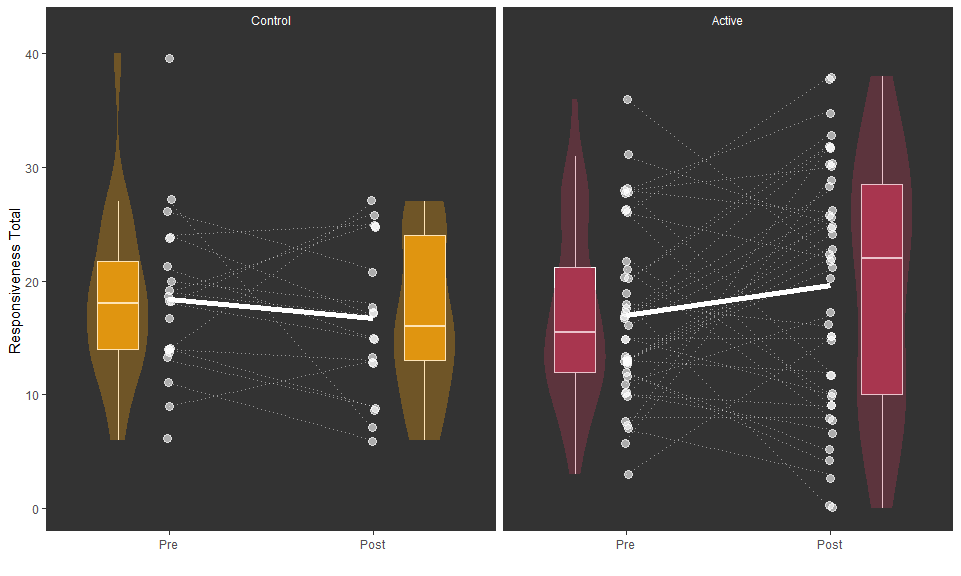

Table. Estimated effect of the intervention on Responsiveness Total.

|  | Baseline adjusted |  |  | Covariate adjusted |  |  |
| --- | --- | --- | --- | --- | --- | --- |
| Predictors | Estimates | CI | p | Estimates | CI | p |
| Intercept | 16.16 | 11.57 – 20.76 | **<0.001** | 16.11 | 11.28 – 20.94 | **<0.001** |
| Active (vs Control) | 3.17 | -2.34 – 8.68 | 0.253 | 3.27 | -2.52 – 9.06 | 0.262 |
| Baseline Responsiveness Total | 0.37 | 0.02 – 0.72 | **0.040** | 0.38 | -0.00 – 0.76 | 0.050 |
| Age (m) |  |  |  | 0.04 | -0.45 – 0.53 | 0.869 |
| Previous SLT (vs None) |  |  |  | -0.10 | -6.53 – 6.33 | 0.975 |
| Observations | 53 |  |  | 53 |  |  |
| R<sup>2</sup> / R<sup>2</sup> adjusted | 0.099 / 0.063 |  |  | 0.099 / 0.024 |  |  |

## Responsiveness Rate

Figure. Individual level change in Responsiveness Rate by study arm.

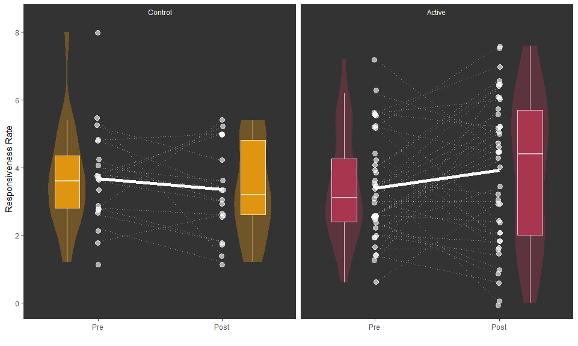

|  | Baseline adjusted |  |  | Covariate adjusted |  |  |
| --- | --- | --- | --- | --- | --- | --- |
| Predictors | Estimates | CI | p | Estimates | CI | p |
| Intercept | 3.23 | 2.31 – 4.15 | **<0.001** | 3.22 | 2.26 – 4.19 | **<0.001** |
| Active (vs Control) | 0.63 | -0.47 – 1.74 | 0.253 | 0.65 | -0.50 – 1.81 | 0.262 |
| Baseline Responsiveness Total | 0.37 | 0.02 – 0.72 | **0.040** | 0.38 | -0.00 – 0.76 | 0.050 |
| Age (m) |  |  |  | 0.01 | -0.09 – 0.11 | 0.869 |
| Previous SLT (vs None) |  |  |  | -0.02 | -1.31 – 1.27 | 0.975 |
| Observations | 53 |  |  | 53 |  |  |
| R<sup>2</sup> / R<sup>2</sup> adjusted | 0.099 / 0.063 |  |  | 0.099 / 0.024 |  |  |

## PaRRiS

Figure. Individual level change in PaRRiS by study arm.

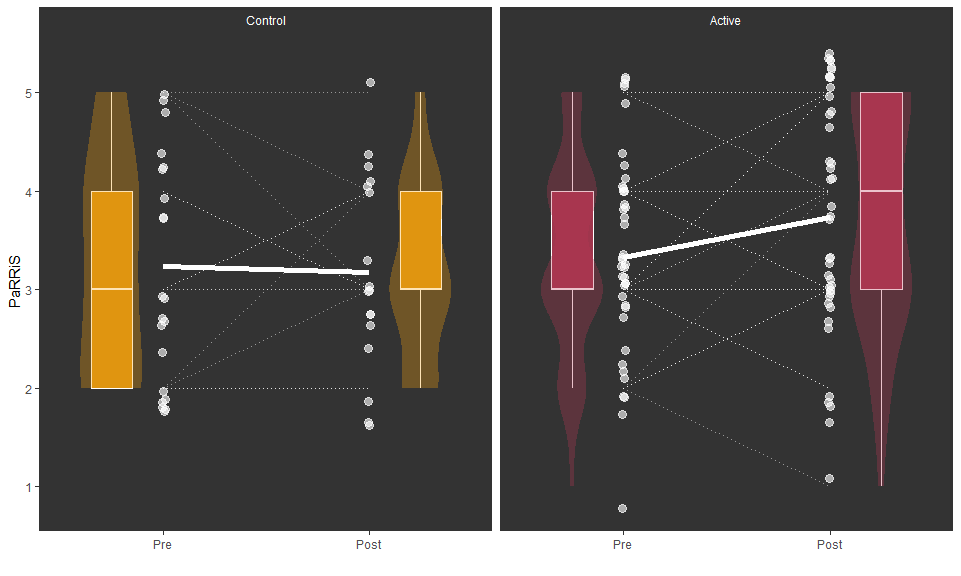

Table. Estimated effect of the intervention on PaRRiS.

|  | Baseline adjusted |  |  | Covariate adjusted |  |  |
| --- | --- | --- | --- | --- | --- | --- |
| Predictors | Estimates | CI | p | Estimates | CI | p |
| Intercept | 3.27 | 2.81 – 3.73 | **<0.001** | 3.27 | 2.79 – 3.75 | **<0.001** |
| Active (vs Control) | 0.38 | -0.18 – 0.94 | 0.178 | 0.42 | -0.16 – 0.99 | 0.156 |
| Baseline PaRRiS | 0.47 | 0.21 – 0.73 | **0.001** | 0.46 | 0.19 – 0.73 | **0.001** |
| Age (m) |  |  |  | 0.01 | -0.03 – 0.06 | 0.566 |
| Previous SLT (vs None) |  |  |  | -0.13 | -0.82 – 0.55 | 0.694 |
| Observations | 52 |  |  | 52 |  |  |
| R<sup>2</sup> / R<sup>2</sup> adjusted | 0.239 / 0.208 |  |  | 0.246 / 0.182 |  |  |

Data Frame Summary

data

**Dimensions**: 81 x 62  
**Duplicates**: 0

[output not shown]

Generated by summarytools 0.9.6 ([R](https://www.r-project.org/) version 3.6.3)  
2020-06-15

[output not shown]